# HLB Bayesian Spatial Modeling in Minas Gerais Brazil

Kaique Alves

26/08/2020

# Packages

```r
library(tidyverse)
library(nasapower)
library(cowplot)
library(ggthemes)
library(rgdal)
library(raster)
library(INLA)
library(spdep)
library(psych)
library(ggsn)
library(gstat)
library(maptools)
library(rnaturalearth)
library(rnaturalearthhires)
source("Bdiclcpomodel_stack.R")
source("coord_transform.R")
```

# Load data

```r
hh_hlb =  read.table("data/hlb_form_map2.txt")  %>%
  mutate(positive = case_when(presenca=="Present" ~ 1,
                              presenca=="Absent" ~ 0)) %>%
  unite("latlon",lat,lon,remove = F) %>%
  group_by(latlon) %>%
  dplyr::filter(positive == max(positive)) %>%
  ungroup() %>%
  dplyr::select(-latlon)
```

transform coordinates to utm

## Download MG shape files

```r
BRA <- ne_states(country = "Brazil", returnclass = "sf")
# subset spatial objects of only the states of interest
MG <- BRA[BRA$name_en == "Minas Gerais", ]
```

```r
MG_shape = readOGR("./data/MG", "MG_Unidade_Federacao_2017_ago")
```

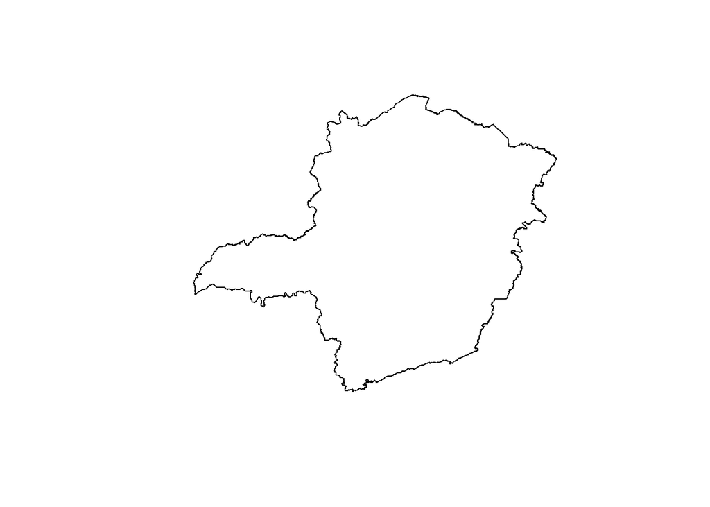

```r
MG_shape = spTransform(MG_shape, CRSobj = "+proj=longlat")
# MG_shape = spTransform(MG_shape,  CRS("+proj=utm +zone=23 +south ellps=WGS84"))
plot(MG_shape)
```

# Maping manipulation

## Create a grid

```r
cs <- c(.4,.4)
# cs <- c(25000,25000)
grdpts =  makegrid(MG_shape, cellsize = cs)

spgrd <- SpatialPoints(grdpts, proj4string = CRS(proj4string(MG_shape)))
```

[figure not shown]

```r
spgrdWithin <- SpatialPixels(spgrd[MG_shape,])
grid_df = as.data.frame(as(spgrdWithin,"SpatialPixelsDataFrame" )@coords)

plot(spgrdWithin)
```

## Counting orchards by grid

### Positive cases

```r
#create dataframe with only positives
hh_hlb_positive = hh_hlb %>%
  filter(positive == 1)

lon = hh_hlb_positive$lon
lat = hh_hlb_positive$lat
xy <- data.frame( lon, lat)
hlb_coords = SpatialPoints(xy,proj4string = CRS(proj4string(MG_shape)))
```

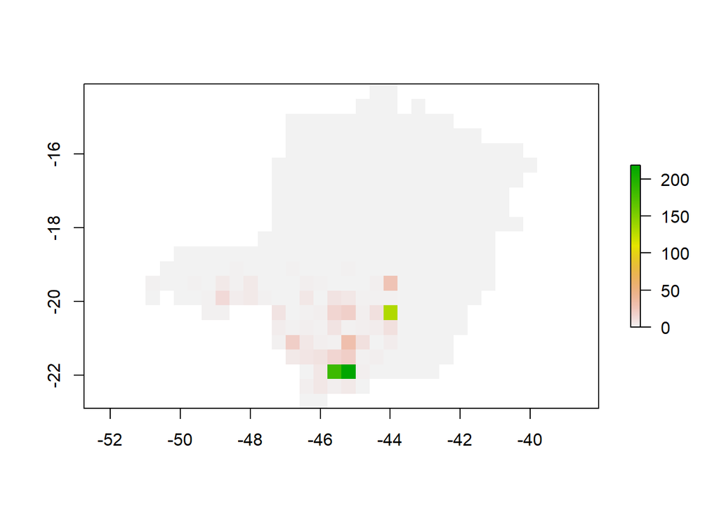

```r
r = raster(spgrdWithin)
r[] <- 0

mg_raster = raster(MG_shape)
mg_raster[] <- 0
rr_positive = mask(r,mask = MG_shape)


tab <- table(cellFromXY(rr_positive, hlb_coords))
rr_positive[as.numeric(names(tab))] <- tab

plot(rr_positive)
```

### Counts by orchard size

```r
# Mini
hh_hlb_mini = hh_hlb %>%
  filter(class=="Mini")
lon = hh_hlb_mini$lon
lat = hh_hlb_mini$lat
xy <- data.frame( lon, lat)
hlb_coords = SpatialPoints(xy,proj4string = CRS(proj4string(MG_shape)))
r = raster(spgrdWithin)
r[] <- 0
mg_raster = raster(MG_shape)
mg_raster[] <- 0
rr_mini = mask(r, mask = MG_shape) #<<<<<
tab <- table(cellFromXY(rr_mini, hlb_coords))#<<<<<
rr_mini[as.numeric(names(tab))] <- tab#<<<<<

# Small
hh_hlb_small = hh_hlb %>%
  filter(class=="Small")
lon = hh_hlb_small$lon#<<<<<
lat = hh_hlb_small$lat#<<<<<
xy <- data.frame( lon, lat)
hlb_coords = SpatialPoints(xy,proj4string = CRS(proj4string(MG_shape)))
r = raster(spgrdWithin)
r[] <- 0
mg_raster = raster(MG_shape)
mg_raster[] <- 0
rr_small = mask(r, mask = MG_shape) #<<<<<
tab <- table(cellFromXY(rr_small, hlb_coords))#<<<<<
rr_small[as.numeric(names(tab))] <- tab#<<<<<

# medium
hh_hlb_medium = hh_hlb %>%
  filter(class=="Medium")
lon = hh_hlb_medium$lon#<<<<<
lat = hh_hlb_medium$lat#<<<<<
xy <- data.frame( lon, lat)
hlb_coords = SpatialPoints(xy,proj4string = CRS(proj4string(MG_shape)))
r = raster(spgrdWithin)
r[] <- 0
mg_raster = raster(MG_shape)
mg_raster[] <- 0
rr_medium = mask(r, mask = MG_shape) #<<<<<
tab <- table(cellFromXY(rr_medium, hlb_coords))#<<<<<
rr_medium[as.numeric(names(tab))] <- tab#<<<<<

# Large
hh_hlb_large = hh_hlb %>%
  filter(class=="Large")
lon = hh_hlb_large$lon#<<<<<
lat = hh_hlb_large$lat#<<<<<
xy <- data.frame( lon, lat)
hlb_coords = SpatialPoints(xy,proj4string = CRS(proj4string(MG_shape)))
```

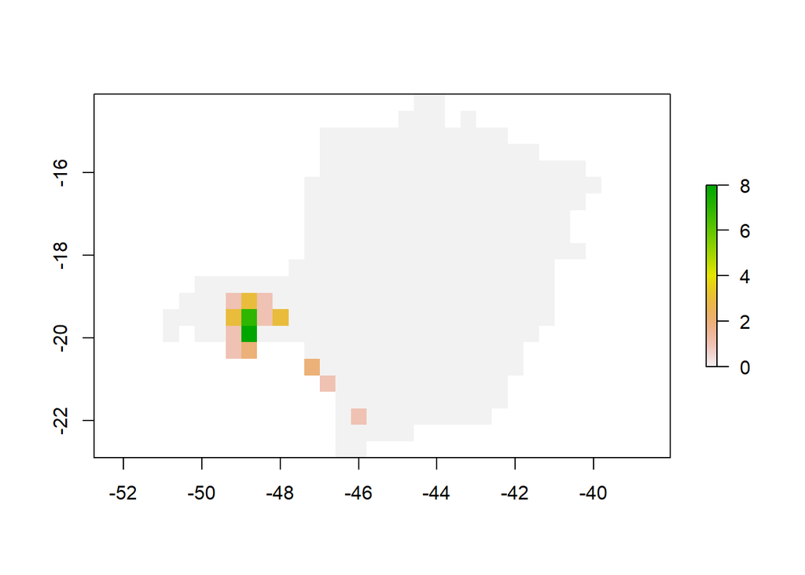

```r
r = raster(spgrdWithin)
r[] <- 0
mg_raster = raster(MG_shape)
mg_raster[] <- 0
rr_large = mask(r, mask = MG_shape) #<<<<<
tab <- table(cellFromXY(rr_large, hlb_coords))#<<<<<
rr_large[as.numeric(names(tab))] <- tab#<<<<<
plot(rr_large)
```

### Count by species

```r
# Orange
hh_hlb_orange = hh_hlb %>%
  filter(especie=="Sweet orange")
lon = hh_hlb_orange$lon
lat = hh_hlb_orange$lat
xy <- data.frame( lon, lat)
hlb_coords = SpatialPoints(xy,proj4string = CRS(proj4string(MG_shape)))
r = raster(spgrdWithin)
r[] <- 0
mg_raster = raster(MG_shape)
mg_raster[] <- 0
rr_orange = mask(r, mask = MG_shape) #<<<<<
tab <- table(cellFromXY(rr_orange, hlb_coords))#<<<<<
rr_orange[as.numeric(names(tab))] <- tab#<<<<<

# Mandarin
hh_hlb_mandarin = hh_hlb %>%
  filter(especie=="Mandarins")
lon = hh_hlb_mandarin$lon#<<<<<
lat = hh_hlb_mandarin$lat#<<<<<
xy <- data.frame( lon, lat)
hlb_coords = SpatialPoints(xy,proj4string = CRS(proj4string(MG_shape)))
r = raster(spgrdWithin)
r[] <- 0
mg_raster = raster(MG_shape)
mg_raster[] <- 0
rr_mandarin = mask(r, mask = MG_shape) #<<<<<
tab <- table(cellFromXY(rr_mandarin, hlb_coords))#<<<<<
rr_mandarin[as.numeric(names(tab))] <- tab#<<<<<

# Lemon
hh_hlb_lemon = hh_hlb %>%
  filter(especie=="Lemon")
lon = hh_hlb_lemon$lon#<<<<<
lat = hh_hlb_lemon$lat#<<<<<
xy <- data.frame( lon, lat)
hlb_coords = SpatialPoints(xy,proj4string = CRS(proj4string(MG_shape)))
r = raster(spgrdWithin)
r[] <- 0
mg_raster = raster(MG_shape)
mg_raster[] <- 0
rr_lemon = mask(r, mask = MG_shape) #<<<<<
tab <- table(cellFromXY(rr_lemon, hlb_coords))#<<<<<
rr_lemon[as.numeric(names(tab))] <- tab#<<<<<

# acide lime
hh_hlb_acidlime = hh_hlb %>%
  filter(especie=="Acid lime")
lon = hh_hlb_acidlime$lon#<<<<<
lat = hh_hlb_acidlime$lat#<<<<<
xy <- data.frame( lon, lat)
hlb_coords = SpatialPoints(xy,proj4string = CRS(proj4string(MG_shape)))
```

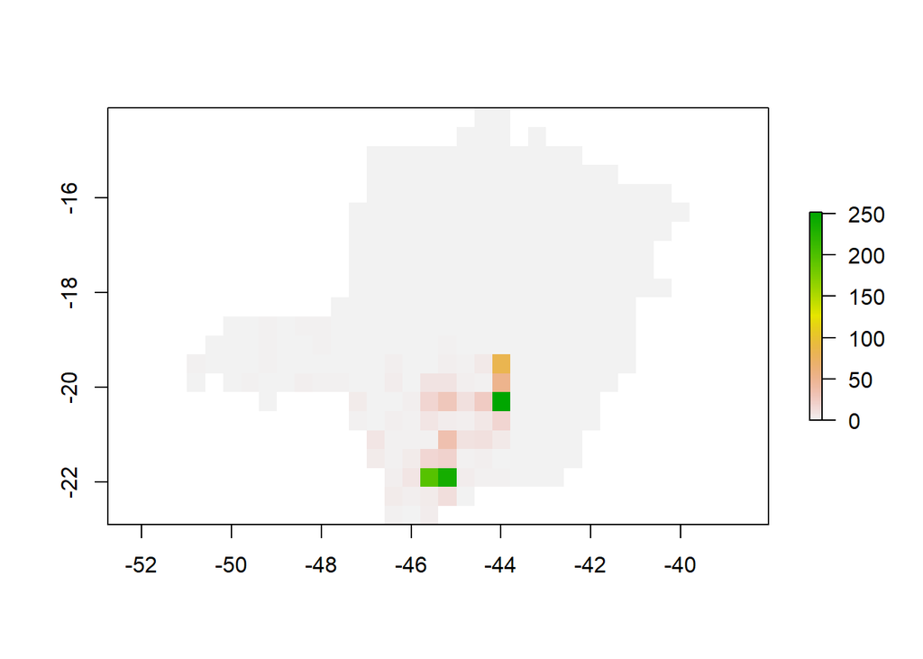

```r
r = raster(spgrdWithin)
r[] <- 0
mg_raster = raster(MG_shape)
mg_raster[] <- 0
rr_acidlime = mask(r, mask = MG_shape) #<<<<<
tab <- table(cellFromXY(rr_acidlime, hlb_coords))#<<<<<
rr_acidlime[as.numeric(names(tab))] <- tab#<<<<<
plot(rr_mandarin)
```

### Mean area

```r
lon = hh_hlb$lon
lat = hh_hlb$lat
xy <- data.frame( lon, lat)
hlb_coords = SpatialPoints(xy,proj4string = CRS(proj4string(MG_shape)))
```

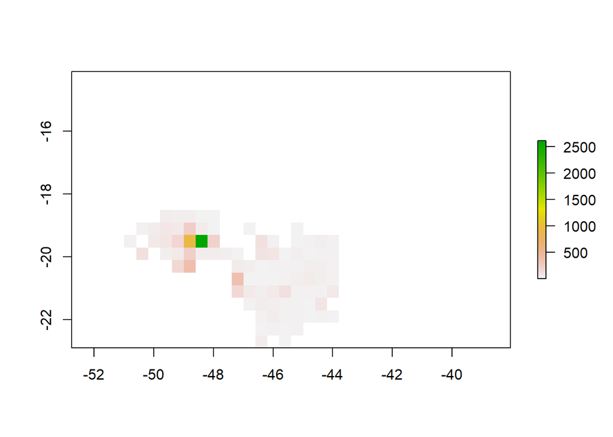

```r
r = raster(spgrdWithin)
df_area =  aggregate(hh_hlb[, 'area', drop=FALSE], hh_hlb[,3:2], mean)
coordinates(df_area) <- ~ lon + lat
# extent(r) <- extent(df_area)
rr_area =  rasterize(df_area, r, df_area$area, fun = mean)
plot(rr_area)
```

```r
# rr_area
# rr
```

### Count All orchards (positives and negatives)

```r
lon = hh_hlb$lon
lat = hh_hlb$lat
xy <- data.frame( lon, lat)
hlb_coords = SpatialPoints(xy,proj4string = CRS(proj4string(MG_shape)))
```

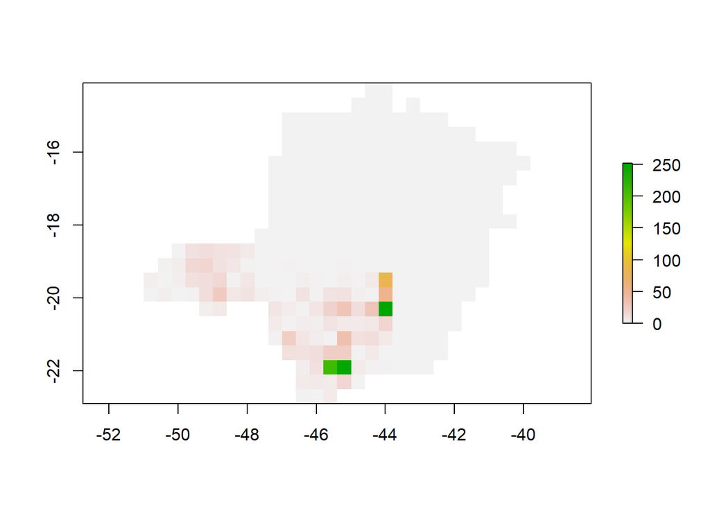

```r
r = raster(spgrdWithin)
r[] <- 0

mg_raster = raster(MG_shape)
mg_raster[] <- 0
rr = mask(r, mask = MG_shape)


tab <- table(cellFromXY(rr, hlb_coords))
rr[as.numeric(names(tab))] <- tab
plot(rr)
```

```r
rr2 = rr>0 & !is.na(rr)
grid_df = as.data.frame(as(rr2, "SpatialPixels")@coords) %>%
  mutate(samp = rr2[]) %>%
  filter(samp ==TRUE)
```

## Map: Disease grid

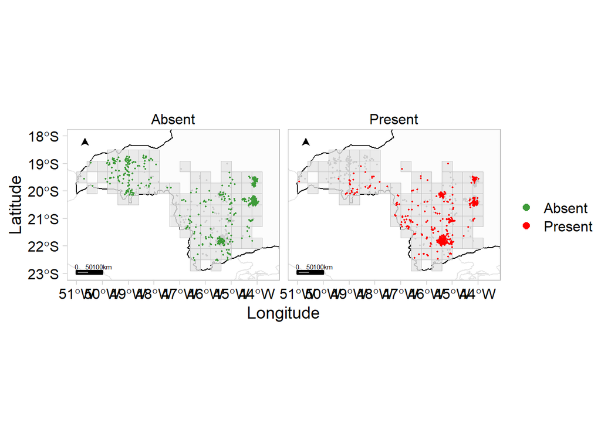

```r
ggplot()+
  geom_sf( data = BRA, fill = "white", color = "gray90")+
  geom_sf(data = MG, fill = "gray99", color = "black") +
  geom_tile(data =grid_df,aes(x,y),
            fill ="gray90",
            size = .2,
            color = "gray75", alpha = 0.8)+
  geom_point(data = hh_hlb %>% dplyr::select(-presenca),
             aes(lon, lat),
             size = 0.3, color = "gray80")+
  geom_point(data = hh_hlb,
             aes(lon, lat, color = presenca),
             size = 0.3, alpha = 1)+
  scale_color_manual(values  =c("#3e9b39", 'red'))+
  coord_sf() +
  guides(color = guide_legend(override.aes = list(size=2.5)))+
  theme_minimal_grid()+
  labs(x = "Longitude",
       y = "Latitude",
       color = "")+
  north( location = "topleft", scale = 0.08, symbol = 10,
      x.min=-51, x.max=-43.5, y.min=-23, y.max=-18)+

  scalebar(location = "bottomleft", dist = 50,
           dist_unit = "km", transform = TRUE,
           x.min=-51, x.max=-44, y.min=-23, y.max=-18,
           st.bottom = FALSE,
           st.dist = 0.03, st.size = 2)+
  ylim(-23, -18)+
  xlim(-51, -43.5)+
  facet_wrap(~presenca)+
  theme(panel.border = element_rect(color = "gray"))
```

```r
# ylim(-22.5, -21.5)+
#   xlim(-46, -44)

ggsave("figs/map_disease.png", dpi = 600, height = 4, width = 11)
```

### Tyding

```r
grid_incidence = data.frame(coordinates(rr),
                            samples=rr[],
                            positives = rr_positive[],
                            area = rr_area[],
                            large = rr_large[],
                            medium = rr_medium[],
                            small = rr_small[],
                            mini=rr_mini[],
                            orange=rr_orange[],
                            mandarin = rr_mandarin[],
                            lemon=rr_lemon[],
                            acid_lime=rr_acidlime[]) %>%
  mutate(samples = replace_na(samples , 0),
         positives = replace_na(positives , 0),
         area = replace_na(area , 0),
         large = replace_na(large , 0),
         medium = replace_na(medium , 0),
         small = replace_na(small , 0),
         mini=replace_na(mini , 0),
         orange=replace_na(orange , 0),
         mandarin = replace_na(mandarin , 0),
         lemon=replace_na(lemon , 0),
         acid_lime=replace_na(acid_lime , 0)) %>%
  filter(samples>0)

min(grid_incidence$area)
```

```
## [1] 0.5
```

### Transform coordinates to UTM

```r
long = grid_incidence$x
lat = grid_incidence$y
xy <- data.frame(ID = 1:(length(lat)), long, lat)
coordinates(xy) <- c("long", "lat")
proj4string(xy) <- CRS("+init=epsg:4326")
res <- spTransform(xy, CRS("+proj=utm +zone=23 +south ellps=WGS84"))
coords_grid = as.data.frame(res)
coords2 = as.matrix(coords_grid[,2:3])
colnames(coords2) <- c("x1","x2")
# max(coords_grid$long)-min(coords_grid$long)
```

### Neighborhood structure

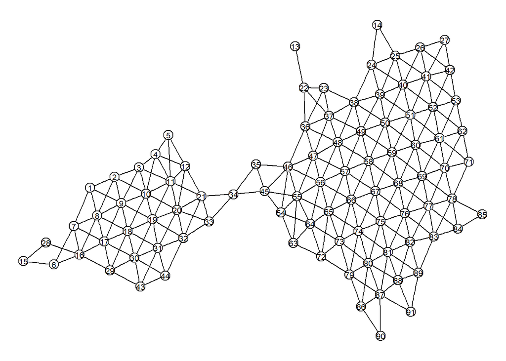

```r
ID <- 1:dim(coords2)[1]
col.nb.0.all <- dnearneigh(coords2, 0, 70000, row.names=ID)
nb2INLA("./models/grid25.graph", col.nb.0.all)
grid_grafo25 <- inla.read.graph("./models/grid25.graph")

plot(grid_grafo25)
```

### Moran’s test

Moran’s I test for spatial autocorrelation

```r
prop <- grid_incidence$positives/grid_incidence$samples
listw<- nb2listw(col.nb.0.all, zero.policy = T)
moran.test(prop, listw,zero.policy=T)
```

```
##
##  Moran I test under randomisation
##
## data:  prop
## weights: listw
##
## Moran I statistic standard deviate = 4.8088, p-value = 7.591e-07
## alternative hypothesis: greater
## sample estimates:
## Moran I statistic       Expectation          Variance
##       0.291327369      -0.011111111       0.003955449
```

# Download climatologic data

## Nasa Power

Correcting coordinates values

```r
power_load= read.table("data/power_data.txt") %>%
  mutate(LON = LON-0.00001,
         LAT = LAT-0.00001)
head(power_load)
```

| LON | LAT | PARAMETER | JAN | FEB | MAR | APR | MAY | JUN | JUL | AUG | SEP | OCT | NOV | DEC | ANN |
| --- | --- | --- | --- | --- | --- | --- | --- | --- | --- | --- | --- | --- | --- | --- | --- |
| -49.6 | -18.7 | T2M | 24.90 | 24.85 | 24.56 | 23.84 | 21.77 | 20.99 | 21.56 | 23.99 | 26.48 | 27.36 | 26.30 | 25.30 | 24.33 |
| -49.6 | -18.7 | PRECTOT | 8.06 | 6.72 | 5.83 | 2.44 | 1.05 | 0.54 | 0.23 | 0.52 | 1.85 | 3.42 | 5.74 | 7.41 | 3.65 |
| -49.6 | -18.7 | WS10M | 2.69 | 2.44 | 2.49 | 2.71 | 2.93 | 3.19 | 3.69 | 3.97 | 3.90 | 3.29 | 2.91 | 2.84 | 3.09 |
| -49.2 | -18.7 | T2M | 24.32 | 24.31 | 24.01 | 23.26 | 21.13 | 20.15 | 20.64 | 22.93 | 25.56 | 26.51 | 25.53 | 24.65 | 23.58 |
| -49.2 | -18.7 | PRECTOT | 8.14 | 6.75 | 5.90 | 2.46 | 1.05 | 0.49 | 0.22 | 0.53 | 1.58 | 3.19 | 5.49 | 7.66 | 3.62 |
| -49.2 | -18.7 | WS10M | 2.87 | 2.61 | 2.67 | 2.90 | 3.08 | 3.41 | 3.93 | 4.22 | 4.13 | 3.48 | 3.08 | 2.98 | 3.28 |

## Full dataset

```r
dry_months = c("MAY","JUN","JUL","AUG")
power_tidy  = power_load %>%
  unite("latlong",LON,LAT) %>%
  gather(3:14, key = "month", value = "measurement") %>%
  mutate(season = case_when(month %in% dry_months ~"dry",
                            !month %in% dry_months ~"rainy")) %>%
  group_by(latlong, PARAMETER, ANN, season) %>%
  summarise(mean = mean(measurement)) %>%
  spread(season, mean) %>%
  ungroup()
data = bind_cols(
power_tidy %>%
  filter(PARAMETER == "PRECTOT") %>%
  mutate(prec_ann= ANN, prec_dry= dry, prec_rainy= rainy) %>%
  dplyr::select(-ANN, -dry, -rainy,-PARAMETER),

power_tidy%>%
  filter(PARAMETER == "T2M") %>%
  mutate(temp_ann= ANN, temp_dry= dry, temp_rainy= rainy) %>%
  dplyr::select(-ANN, -dry, -rainy,-PARAMETER,-latlong),

power_tidy%>%
  filter(PARAMETER == "WS10M") %>%
  mutate(wind_ann= ANN, wind_dry= dry, wind_rainy= rainy) %>%
  dplyr::select(-ANN, -dry, -rainy,-PARAMETER,-latlong)
) %>%
  separate(latlong, into = c("x", "y"), sep = "_", convert = TRUE) %>%
  arrange(x,y) %>%
  bind_cols(
    grid_incidence %>%
      arrange(x,y) %>%
      mutate(large_area = medium+large,
             small_area = mini+small,
             #mandarin = log(mandarin+1),
             #orange = log(orange+1)
             ) %>%
      dplyr::select(-x,-y)) %>%
  mutate(area = log(area)) %>%
  # Add a column for random effect
  mutate(S = 1:length(grid_incidence[,1]))

head(data)
```

| x | y | prec_ann | prec_dry | prec_rainy | temp_ann | temp_dry | temp_rainy | wind_ann | wind_dry | wind_rainy | samples | positives | area | large | medium | small | mini | orange | mandarin | lemon | acid_lime | large_area | small_area | S |
| --- | --- | --- | --- | --- | --- | --- | --- | --- | --- | --- | --- | --- | --- | --- | --- | --- | --- | --- | --- | --- | --- | --- | --- | --- |
| -50.8 | -19.5 | 3.77 | 0.7175 | 5.30125 | 24.63 | 22.1425 | 25.87375 | 2.89 | 3.1275 | 2.77875 | 2 | 1 | 1.996060 | 0 | 0 | 0 | 2 | 1 | 1 | 0 | 0 | 0 | 2 | 1 |
| -50.4 | -19.9 | 3.68 | 0.7875 | 5.12375 | 24.40 | 21.6250 | 25.79500 | 3.14 | 3.3700 | 3.02250 | 2 | 0 | 4.653484 | 0 | 2 | 0 | 0 | 0 | 0 | 0 | 2 | 2 | 0 | 2 |
| -50.4 | -19.1 | 3.71 | 0.6725 | 5.22875 | 24.47 | 21.9725 | 25.71375 | 3.02 | 3.2975 | 2.87875 | 1 | 0 | 2.302585 | 0 | 0 | 0 | 1 | 1 | 0 | 0 | 0 | 0 | 1 | 3 |
| -50.0 | -19.5 | 3.71 | 0.6525 | 5.23000 | 23.93 | 21.3500 | 25.22750 | 3.12 | 3.4175 | 2.97750 | 2 | 0 | 3.931826 | 0 | 1 | 1 | 0 | 2 | 0 | 0 | 0 | 1 | 1 | 4 |
| -50.0 | -19.1 | 3.71 | 0.6525 | 5.23000 | 23.93 | 21.3500 | 25.22750 | 3.12 | 3.4175 | 2.97750 | 3 | 0 | 3.304442 | 0 | 0 | 3 | 0 | 3 | 0 | 0 | 0 | 0 | 3 | 5 |
| -49.6 | -19.9 | 3.73 | 0.7650 | 5.20500 | 23.96 | 21.1050 | 25.39375 | 3.15 | 3.3700 | 3.04375 | 1 | 0 | 2.995732 | 0 | 0 | 1 | 0 | 0 | 1 | 0 | 0 | 0 | 1 | 6 |

###Scaling

```r
# data= dataa %>%
#   mutate(prec_rainy = scale(prec_rainy),
#          temp_dry = scale(temp_dry),
#          wind_ann = scale(wind_ann),
#          area = (area),
#          mandarin = log(mandarin+1),
#          orange = log(orange+1))
```

### Correlation

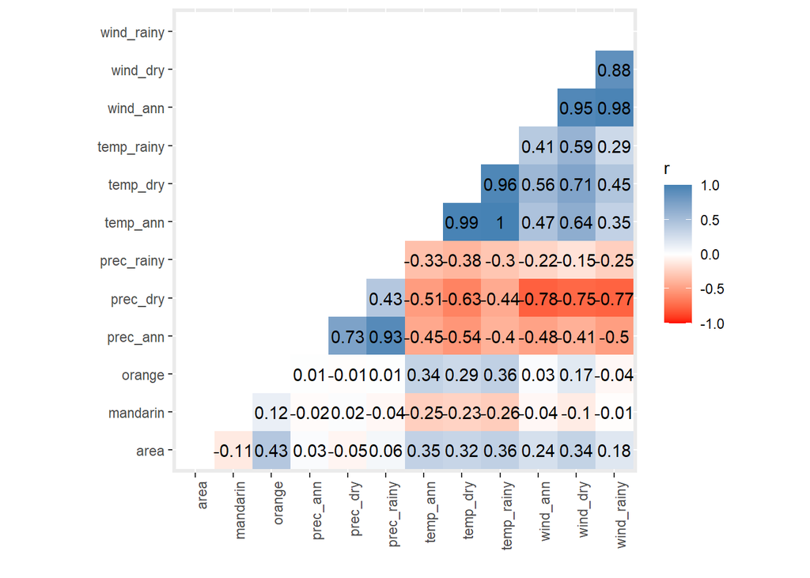

```r
correl = cor(data[c(3:11,14,20:19)])

xy <- expand.grid(x=1:12,y=12:1)

a=rowSums(xy)/12
as.data.frame(correl) %>%
  rownames_to_column(var = "var1") %>%
  gather(2:13, key = "var", value = "value") %>%
  mutate(value = round(value,2)) %>%
  arrange(var1, var) %>%
  mutate(aa= round(a,3)) %>%
  # filter(aa<=0.52) %>%
  mutate(value = case_when(aa <= 1 ~ value,
                           aa > 1 ~ NA_real_)) %>%
  ggplot(aes(var1,var,fill = value, label = value)) +
  geom_tile()+
  geom_text()+
  coord_equal()+
  scale_fill_gradient2(low = "red", mid = "white", high = "steelblue",
                       limits= c(-1,1),na.value="white")+
  theme(axis.text.x = element_text(angle = 90, hjust = 1))+
  labs(x="",
       y = "",
       fill= "r")
```

```r
ggsave("figs/correl.png",dpi = 600, height = 7, width = 8)
```

# Bayesian Modeling

## Model Selection using variables

### Hyperparameters

Simpson et al. (2017) prior distributions for hyperparameters

```r
u <- 0.2/0.31
alpha <- 0.01
phi.u <- 0.5
phi.alpha <- 2/3
```

### Predictor variables

```r
#lembrar de colocar a especie e tamanho da lavoura
# colnames(data)
variables <- c(
  # "large","medium","small","mini",
  "area",
  # "orange",
  # "mandarin",
  # "lemon","acid_lime",
  # "small_area",
  # "large_area",
# "prec_dry",
"prec_rainy",
# "temp_dry",
"temp_dry",
# "wind_dry",
# "wind_rainy",
"wind_ann",
"f(S, model = 'bym2', graph=grid_grafo25, scale.model = TRUE, constr = TRUE,
        hyper=list(phi = list( prior = 'pc', param = c(phi.u, phi.alpha), initial = -3),
        prec = list(prior = 'pc.prec', param = c(u, alpha), initial = 5)))"
)
# 2^6
```

### Response variable

```r
resp<-data$positives
total<-data$samples
```

### Modeling

```r
models_bin<-Bdiclcpomodel_stack(resp=resp, variables=variables,
                                Ntrials=total,
                                datos=data, n=20,
                                family="binomial",
                                control.predictor=list(compute=FALSE),
                                control.compute = list(
                                config=TRUE, dic=TRUE, cpo=TRUE, waic=TRUE),
                                verbose=F)
save(models_bin, file="./models/best_models_clim.RData")
```

### Ranking models by WAIC criteria

```r
models_bin$`Modelos segun waic`[1:10,]
```

| Modelos | Dic | Waic | LCPO | LCPO-failure |
| --- | --- | --- | --- | --- |
| resp ~ 1 + temp_dry + wind_ann + f(S, model = ‘bym2’, graph=grid_grafo25, scale.model = TRUE, constr = TRUE, |  |  |  |  |

```
    hyper=list(phi = list( prior = 'pc', param = c(phi.u, phi.alpha), initial = -3),
    prec = list(prior = 'pc.prec', param = c(u, alpha), initial = 5)))                     | 289.8902| 287.1569| 3.582138|     1.831771|
```

|resp ~ 1 + area + temp_dry + wind_ann + f(S, model = ‘bym2’, graph=grid_grafo25, scale.model = TRUE, constr = TRUE,  
hyper=list(phi = list( prior = ‘pc’, param = c(phi.u, phi.alpha), initial = -3), prec = list(prior = ‘pc.prec’, param = c(u, alpha), initial = 5))) | 289.9658| 287.2445| 3.605226| 1.871398| |resp ~ 1 + prec_rainy + temp_dry + wind_ann + f(S, model = ‘bym2’, graph=grid_grafo25, scale.model = TRUE, constr = TRUE,  
hyper=list(phi = list( prior = ‘pc’, param = c(phi.u, phi.alpha), initial = -3), prec = list(prior = ‘pc.prec’, param = c(u, alpha), initial = 5))) | 290.1758| 287.3756| 3.606311| 1.860893| |resp ~ 1 + area + prec_rainy + temp_dry + wind_ann + f(S, model = ‘bym2’, graph=grid_grafo25, scale.model = TRUE, constr = TRUE,  
hyper=list(phi = list( prior = ‘pc’, param = c(phi.u, phi.alpha), initial = -3), prec = list(prior = ‘pc.prec’, param = c(u, alpha), initial = 5))) | 290.2063| 287.4870| 3.703742| 1.925097| |resp ~ 1 + area + prec_rainy + f(S, model = ‘bym2’, graph=grid_grafo25, scale.model = TRUE, constr = TRUE,  
hyper=list(phi = list( prior = ‘pc’, param = c(phi.u, phi.alpha), initial = -3), prec = list(prior = ‘pc.prec’, param = c(u, alpha), initial = 5))) | 293.1504| 289.5868| 3.624217| 1.970548| |resp ~ 1 + area + temp_dry + f(S, model = ‘bym2’, graph=grid_grafo25, scale.model = TRUE, constr = TRUE,  
hyper=list(phi = list( prior = ‘pc’, param = c(phi.u, phi.alpha), initial = -3), prec = list(prior = ‘pc.prec’, param = c(u, alpha), initial = 5))) | 292.2382| 290.1039| 3.477793| 1.691179| |resp ~ 1 + area + f(S, model = ‘bym2’, graph=grid_grafo25, scale.model = TRUE, constr = TRUE,  
hyper=list(phi = list( prior = ‘pc’, param = c(phi.u, phi.alpha), initial = -3), prec = list(prior = ‘pc.prec’, param = c(u, alpha), initial = 5))) | 293.7477| 290.4239| 3.461486| 1.927860| |resp ~ 1 + area + prec_rainy + temp_dry + f(S, model = ‘bym2’, graph=grid_grafo25, scale.model = TRUE, constr = TRUE,  
hyper=list(phi = list( prior = ‘pc’, param = c(phi.u, phi.alpha), initial = -3), prec = list(prior = ‘pc.prec’, param = c(u, alpha), initial = 5))) | 292.5277| 290.4247| 3.525270| 1.648551| |resp ~ 1 + prec_rainy + f(S, model = ‘bym2’, graph=grid_grafo25, scale.model = TRUE, constr = TRUE,  
hyper=list(phi = list( prior = ‘pc’, param = c(phi.u, phi.alpha), initial = -3), prec = list(prior = ‘pc.prec’, param = c(u, alpha), initial = 5))) | 293.8329| 290.4345| 3.540200| 1.845202| |resp ~ 1 + temp_dry + f(S, model = ‘bym2’, graph=grid_grafo25, scale.model = TRUE, constr = TRUE,  
hyper=list(phi = list( prior = ‘pc’, param = c(phi.u, phi.alpha), initial = -3), prec = list(prior = ‘pc.prec’, param = c(u, alpha), initial = 5))) | 292.5081| 290.5057| 3.483792| 1.645850|

### Best model

```r
# models_bin$`Modelos segun waic`[1,1]

f1 <- positives ~ 1 + temp_dry + wind_ann + f(S, model = "bym2",
                        graph=grid_grafo25,
                        scale.model = TRUE,
                        constr = TRUE,
                        hyper=list(
                                phi = list(
                                        prior = "pc",
                                        param = c(phi.u, phi.alpha),
                                        initial = -3),
                                prec = list(
                                        prior = "pc.prec",
                                        param = c(u, alpha),
                                        initial = 5)))
mod<-inla(f1, family="binomial", data=data, Ntrials = samples,
          control.compute=list(dic=TRUE,cpo=TRUE, waic=TRUE), verbose = FALSE)
# bym2
```

```r
mod <- inla.rerun(mod)
saveRDS(mod, "./models/best_model.RDS")
```

### Summary statistics

```r
# mod$logfile
summary(mod)
```

```
##
## Call:
##    c("inla(formula = f1, family = \"binomial\", data = data, Ntrials =
##    samples, ", " verbose = FALSE, control.compute = list(dic = TRUE, cpo =
##    TRUE, ", " waic = TRUE))")
## Time used:
##     Pre = 11.4, Running = 3.27, Post = 0.112, Total = 14.7
## Fixed effects:
##               mean    sd 0.025quant 0.5quant 0.975quant   mode kld
## (Intercept) 10.468 2.556      5.586   10.412     15.667 10.295   0
## temp_dry    -0.764 0.184     -1.147   -0.756     -0.425 -0.739   0
## wind_ann     1.050 0.585     -0.051    1.033      2.248  0.997   0
##
## Random effects:
##   Name     Model
##     S BYM2 model
##
## Model hyperparameters:
##                  mean    sd 0.025quant 0.5quant 0.975quant  mode
## Precision for S 0.600 0.174      0.331    0.575      1.010 0.529
## Phi for S       0.343 0.232      0.023    0.307      0.827 0.059
##
## Expected number of effective parameters(stdev): 50.47(4.12)
## Number of equivalent replicates : 1.80
##
## Deviance Information Criterion (DIC) ...............: 289.89
## Deviance Information Criterion (DIC, saturated) ....: 157.28
## Effective number of parameters .....................: 49.25
##
## Watanabe-Akaike information criterion (WAIC) ...: 287.16
## Effective number of parameters .................: 35.58
##
## Marginal log-Likelihood:  -149.96
## CPO and PIT are computed
##
## Posterior marginals for the linear predictor and
##  the fitted values are computed
```

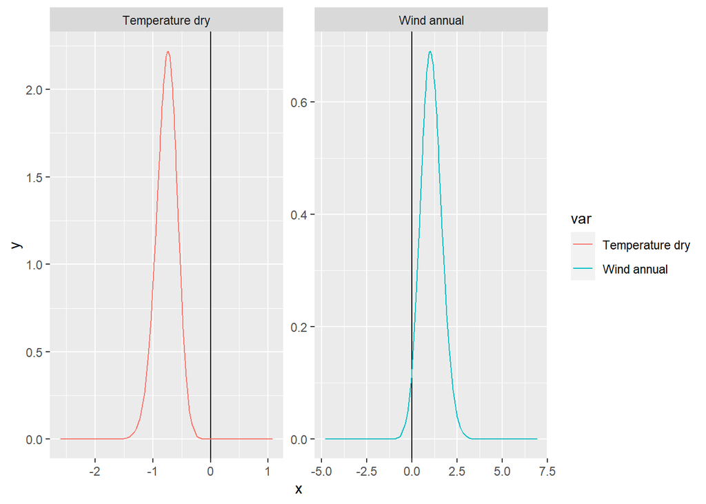

```r
bind_rows(#as.data.frame(mod$marginals.fixed$mandarin) %>%
     # mutate(var = "Mandarin"),
   # as.data.frame(mod$marginals.fixed$prec_dry) %>%
   # mutate(var = "prec_dry"),
    as.data.frame(mod$marginals.fixed$temp_dry) %>%
      mutate(var = "Temperature dry"),
    as.data.frame(mod$marginals.fixed$wind_ann) %>%
      mutate(var = "Wind annual")
) %>%
  ggplot(aes(x, y, color = var))+
  geom_vline(xintercept = 0)+
  geom_line()+
  facet_wrap(~var, scales = "free")
```

### Posterior distributions

#### Spatial effect.

##### Mean

```r
rr2 = rr>0
### --- Mean of the structured effect --- ###
rr2[as.numeric(names(tab))] <- mod$summary.random$S$mean[1:nrow(data)]
df = as(rr2, "SpatialPixelsDataFrame")
test_df <- as.data.frame(df)
colnames(test_df) <- c("value", "x", "y")
g_spt_v = ggplot(test_df %>%
         filter(value!=0)) +
  geom_sf( data = BRA, fill = "white", color = "gray60")+
  geom_sf(data = MG, fill = "white", color = "black") +
  geom_tile(aes(x=x, y=y, fill=value), alpha=1)+
  scale_fill_viridis_c(option = "E")+
  coord_sf() +
  theme_minimal_grid(font_size = 8)+
  labs(x = "Longitude",
       y = "Latitude",
       fill = "")+
  north( location = "topleft", scale = 0.08, symbol = 10,
      x.min=-51, x.max=-43.5, y.min=-23, y.max=-18)+

  scalebar(location = "bottomleft", dist = 50,
           dist_unit = "km", transform = TRUE,
           x.min=-51, x.max=-44, y.min=-23, y.max=-18,
           st.bottom = FALSE,
           st.dist = 0.03, st.size = 2)+
  ylim(-23, -18)+
  xlim(-51, -43.5)+
  theme(panel.border = element_rect(color = "gray"))
```

##### Standard deviation

```r
rr2 = rr>0
### --- Mean of the structured effect --- ###
rr2[as.numeric(names(tab))] <- mod$summary.random$S$sd[1:nrow(data)]
df = as(rr2, "SpatialPixelsDataFrame")
test_df <- as.data.frame(df)
colnames(test_df) <- c("value", "x", "y")
g_spt_v_sd = ggplot(test_df %>%
         filter(value!=0)) +
  geom_sf( data = BRA, fill = "white", color = "gray60")+
  geom_sf(data = MG, fill = "white", color = "black") +
  geom_tile(aes(x=x, y=y, fill=value), alpha=0.95)+
   scale_fill_gradient(low = "white", high = "#37bf87")+
  coord_sf() +
  theme_minimal_grid(font_size = 8)+
  labs(x = "Longitude",
       y = "Latitude",
       fill = "")+
  north( location = "topleft", scale = 0.08, symbol = 10,
      x.min=-51, x.max=-43.5, y.min=-23, y.max=-18)+

  scalebar(location = "bottomleft", dist = 50,
           dist_unit = "km", transform = TRUE,
           x.min=-51, x.max=-44, y.min=-23, y.max=-18,
           st.bottom = FALSE,
           st.dist = 0.03, st.size = 2)+
  ylim(-23, -18)+
  xlim(-51, -43.5)+
  theme(panel.border = element_rect(color = "gray"))
```

#### RISK

##### Mean propability

```r
rr2[as.numeric(names(tab))] <- mod$summary.fitted.values$mean

# plot(rr2)

df = as(rr2, "SpatialPixelsDataFrame")
test_df <- as.data.frame(df)
colnames(test_df) <- c("value", "x", "y")
g1_v = ggplot(test_df %>%
         filter(value>0))+
  geom_sf( data = BRA, fill = "white", color = "gray60")+
  geom_sf(data = MG, fill = "white", color = "black") +
  geom_tile(aes(x=x, y=y, fill=value), alpha=0.95)+
  # geom_point(data = hh_hlb,
  #            aes(lon, lat, color = presenca),
  #            size = 0.4)+
  # scale_color_manual(values  =c("black","red"))+
  scale_fill_distiller(palette = "YlOrRd", direction = 1)+
  coord_sf() +
  theme_minimal_grid(font_size = 8)+
  labs(x = "Longitude",
       y = "Latitude",
       fill = "")+
  north( location = "topleft", scale = 0.08, symbol = 10,
      x.min=-51, x.max=-43.5, y.min=-23, y.max=-18)+

  scalebar(location = "bottomleft", dist = 50,
           dist_unit = "km", transform = TRUE,
           x.min=-51, x.max=-44, y.min=-23, y.max=-18,
           st.bottom = FALSE,
           st.dist = 0.03, st.size = 2)+
  ylim(-23, -18)+
  xlim(-51, -43.5)+
  theme(panel.border = element_rect(color = "gray"))

# ggsave("figs/map_posterior.png", dpi = 600, height = 5, width = 8)
```

##### Standard deviation

```r
rr2[as.numeric(names(tab))] <- mod$summary.fitted.values$sd
df = as(rr2, "SpatialPixelsDataFrame")
test_df <- as.data.frame(df)
colnames(test_df) <- c("value", "x", "y")
g1_v_sd = ggplot(test_df %>%
         filter(value>0))+
  geom_sf( data = BRA, fill = "white", color = "gray60")+
  geom_sf(data = MG, fill = "gray99", color = "black") +
  geom_tile(aes(x=x, y=y, fill=value), alpha=0.95)+
  # scale_fill_viridis_c(option = "B") +
  scale_color_manual(values  ="black")+
   scale_fill_gradient(low = "white", high = "steelblue")+
  coord_sf() +
  theme_minimal_grid(font_size = 8)+
  labs(x = "Longitude",
       y = "Latitude",
       fill = "")+
  north( location = "topleft", scale = 0.08, symbol = 10,
      x.min=-51, x.max=-43.5, y.min=-23, y.max=-18)+

  scalebar(location = "bottomleft", dist = 50,
           dist_unit = "km", transform = TRUE,
           x.min=-51, x.max=-44, y.min=-23, y.max=-18,
           st.bottom = FALSE,
           st.dist = 0.03, st.size = 2)+
  ylim(-23, -18)+
  xlim(-51, -43.5)+
  theme(panel.border = element_rect(color = "gray"))
```

##### Combo

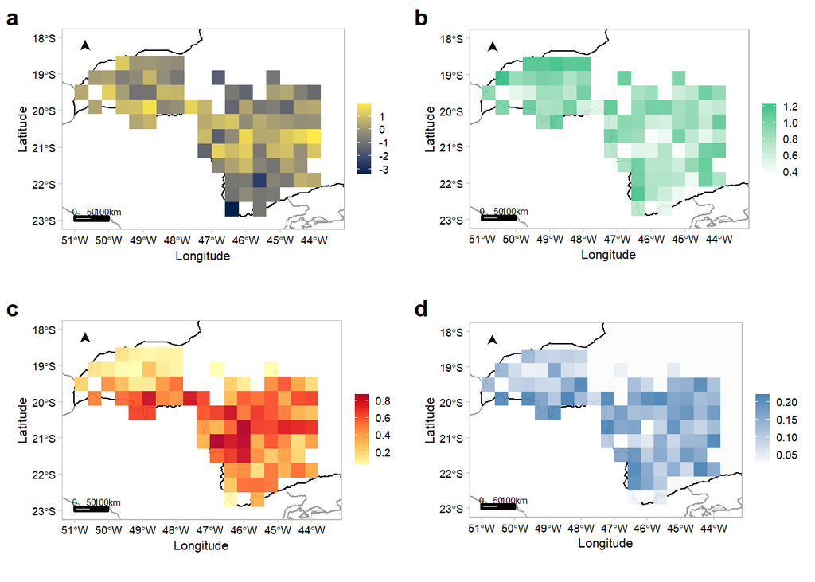

```r
plot_grid(g_spt_v,
          g_spt_v_sd,
          g1_v,
          g1_v_sd,
          labels = "auto",
          scale = 0.95)
```

```r
ggsave("figs/combo_var.png", dpi = 300, height = 6, width = 10)
```

## PCAs as predictors

### Principal component analysis

```r
pca_rotated <- psych::principal(data[c(3:11,14,20:19)], rotate="varimax",
                                nfactors=3,scores=TRUE, covar=FALSE)
pca_rotated$loadings
```

```
##
## Loadings:
##            RC1    RC2    RC3
## prec_ann   -0.371         0.898
## prec_dry   -0.774         0.475
## prec_rainy                0.932
## temp_ann    0.330  0.821 -0.391
## temp_dry    0.437  0.747 -0.438
## temp_rainy  0.268  0.851 -0.362
## wind_ann    0.977  0.127 -0.122
## wind_dry    0.911  0.361
## wind_rainy  0.972        -0.142
## area        0.205  0.617  0.290
## mandarin          -0.322
## orange             0.635  0.120
##
##                  RC1   RC2   RC3
## SS loadings    3.889 3.001 2.516
## Proportion Var 0.324 0.250 0.210
## Cumulative Var 0.324 0.574 0.784
```

```r
# plot(pca_rotated)
```

```r
data_pca<-data[,c(1,2,12,13)]
data_pca$PC1<-pca_rotated$scores[,1]
data_pca$PC2<-pca_rotated$scores[,2]
data_pca$PC3<-pca_rotated$scores[,3]

# data_pca$PC4<-pca_rotated$scores[,4]
# data_pca$PC5<-pca_rotated$scores[,5]
write.table(data_pca, "./data/data_pca")
data_pca<-read.table("./data/data_pca")
```

Add a column for the random effect

```r
data_pca <- data.frame(data_pca, S=c(1:length(data_pca[,1])))
```

### Hyperparameters

Simpson et al. (2017) prior distributions for hyperparameters

```r
u <- 0.2/0.31
alpha <- 0.01
phi.u <- 0.5
phi.alpha <- 2/3
```

### Predictor variables

```r
variables <- c(
        paste("PC", c(1, 2, 3), sep = ""),
        "f(S, model = 'bym2', graph=grid_grafo25, scale.model = TRUE, constr = TRUE,
        hyper=list(phi = list( prior = 'pc', param = c(phi.u, phi.alpha), initial = -3),
        prec = list(prior = 'pc.prec', param = c(u, alpha), initial = 5)))"
)
```

### Response variable

```r
resp<-data_pca$positives
total<-data_pca$samples
```

### Modeling

```r
models_pca<-Bdiclcpomodel_stack(resp=resp, variables=variables,
                                Ntrials=total,
                                datos=data_pca, n=20,
                                family="binomial",
                                control.predictor=list(compute=FALSE),
                                control.compute = list(
                                  config=TRUE, dic=TRUE, cpo=TRUE, waic=TRUE),
                                verbose=FALSE)
save(models_pca, file="./models/best_models_pca.RData")
```

### Ranking models by WAIC

```r
models_pca$`Modelos segun waic`[1:10,]
```

| Modelos | Dic | Waic | LCPO | LCPO-failure |
| --- | --- | --- | --- | --- |
| resp ~ 1 + PC2 + PC3 + f(S, model = ‘bym2’, graph=grid_grafo25, scale.model = TRUE, constr = TRUE, |  |  |  |  |

```
    hyper=list(phi = list( prior = 'pc', param = c(phi.u, phi.alpha), initial = -3),
    prec = list(prior = 'pc.prec', param = c(u, alpha), initial = 5)))       | 290.2614| 286.0155| 3.651664|     1.919868|
```

|resp ~ 1 + PC2 + f(S, model = ‘bym2’, graph=grid_grafo25, scale.model = TRUE, constr = TRUE,  
hyper=list(phi = list( prior = ‘pc’, param = c(phi.u, phi.alpha), initial = -3), prec = list(prior = ‘pc.prec’, param = c(u, alpha), initial = 5))) | 291.6449| 286.8936| 3.595011| 1.835189| |resp ~ 1 + PC1 + PC2 + PC3 + f(S, model = ‘bym2’, graph=grid_grafo25, scale.model = TRUE, constr = TRUE,  
hyper=list(phi = list( prior = ‘pc’, param = c(phi.u, phi.alpha), initial = -3), prec = list(prior = ‘pc.prec’, param = c(u, alpha), initial = 5))) | 291.9592| 287.9956| 3.751064| 1.841816| |resp ~ 1 + PC1 + PC2 + f(S, model = ‘bym2’, graph=grid_grafo25, scale.model = TRUE, constr = TRUE,  
hyper=list(phi = list( prior = ‘pc’, param = c(phi.u, phi.alpha), initial = -3), prec = list(prior = ‘pc.prec’, param = c(u, alpha), initial = 5))) | 293.0395| 288.8244| 3.593485| 1.726358| |resp ~ 1 + PC3 + f(S, model = ‘bym2’, graph=grid_grafo25, scale.model = TRUE, constr = TRUE,  
hyper=list(phi = list( prior = ‘pc’, param = c(phi.u, phi.alpha), initial = -3), prec = list(prior = ‘pc.prec’, param = c(u, alpha), initial = 5))) | 292.7390| 289.7045| 3.640913| 1.814727| |resp ~ 1 + PC1 + PC3 + f(S, model = ‘bym2’, graph=grid_grafo25, scale.model = TRUE, constr = TRUE,  
hyper=list(phi = list( prior = ‘pc’, param = c(phi.u, phi.alpha), initial = -3), prec = list(prior = ‘pc.prec’, param = c(u, alpha), initial = 5))) | 293.6272| 290.6279| 3.572353| 1.899736| |resp ~ 1 + f(S, model = ‘bym2’, graph=grid_grafo25, scale.model = TRUE, constr = TRUE,  
hyper=list(phi = list( prior = ‘pc’, param = c(phi.u, phi.alpha), initial = -3), prec = list(prior = ‘pc.prec’, param = c(u, alpha), initial = 5))) | 294.4201| 291.2162| 3.463111| 1.830511| |resp ~ 1 + PC1 + f(S, model = ‘bym2’, graph=grid_grafo25, scale.model = TRUE, constr = TRUE,  
hyper=list(phi = list( prior = ‘pc’, param = c(phi.u, phi.alpha), initial = -3), prec = list(prior = ‘pc.prec’, param = c(u, alpha), initial = 5))) | 295.6989| 292.4524| 3.508525| 1.749499| |resp ~ 1 + PC1 + PC2 + PC3 | 521.8001| 540.8262| 2.981468| 0.000000| |resp ~ 1 + PC1 + PC2 | 531.6719| 549.7266| 3.030252| 0.000000|

### Best model

```r
f1 <- positives ~ 1 + PC2 + PC3 +  f(S, model = "bym2",
                        graph=grid_grafo25,
                        scale.model = TRUE,
                        constr = TRUE,
                        hyper=list(
                                phi = list(
                                        prior = "pc",
                                        param = c(phi.u, phi.alpha),
                                        initial = -3),
                                prec = list(
                                        prior = "pc.prec",
                                        param = c(u, alpha),
                                        initial = 5)))
mod_pca<-inla(f1, family="binomial", data=data_pca, Ntrials = samples,
          control.compute=list(dic=TRUE,cpo=TRUE, waic=TRUE), verbose = FALSE)
```

```r
mod_pca <- inla.rerun(mod_pca)
saveRDS(mod_pca, "./models/best_model_pca.RDS")
```

### Summary statistics

```r
# mod$logfile
summary(mod_pca)
```

```
##
## Call:
##    c("inla(formula = f1, family = \"binomial\", data = data_pca, Ntrials =
##    samples, ", " verbose = FALSE, control.compute = list(dic = TRUE, cpo =
##    TRUE, ", " waic = TRUE))")
## Time used:
##     Pre = 11.3, Running = 4.17, Post = 0.149, Total = 15.6
## Fixed effects:
##               mean    sd 0.025quant 0.5quant 0.975quant   mode kld
## (Intercept) -0.438 0.170     -0.782   -0.434     -0.113 -0.427   0
## PC2         -0.753 0.278     -1.314   -0.750     -0.211 -0.742   0
## PC3          0.443 0.213      0.030    0.441      0.867  0.437   0
##
## Random effects:
##   Name     Model
##     S BYM2 model
##
## Model hyperparameters:
##                  mean    sd 0.025quant 0.5quant 0.975quant  mode
## Precision for S 0.503 0.139      0.285    0.485      0.828 0.450
## Phi for S       0.424 0.234      0.050    0.411      0.867 0.239
##
## Expected number of effective parameters(stdev): 52.40(3.96)
## Number of equivalent replicates : 1.74
##
## Deviance Information Criterion (DIC) ...............: 290.26
## Deviance Information Criterion (DIC, saturated) ....: 157.65
## Effective number of parameters .....................: 50.98
##
## Watanabe-Akaike information criterion (WAIC) ...: 286.01
## Effective number of parameters .................: 35.62
##
## Marginal log-Likelihood:  -153.63
## CPO and PIT are computed
##
## Posterior marginals for the linear predictor and
##  the fitted values are computed
```

### Posterior distributions

#### Spatial effect.

##### Mean

```r
rr2 = rr>0
### --- Mean of the structured effect --- ###
rr2[as.numeric(names(tab))] <- mod_pca$summary.random$S$mean[1:nrow(data)]
df = as(rr2, "SpatialPixelsDataFrame")
test_df <- as.data.frame(df)
colnames(test_df) <- c("value", "x", "y")
g_spt_pc = ggplot(test_df %>%
         filter(value!=0)) +
  geom_sf( data = BRA, fill = "white", color = "gray60")+
  geom_sf(data = MG, fill = "white", color = "black") +
  geom_tile(aes(x=x, y=y, fill=value), alpha=0.95)+
  scale_fill_viridis_c(option = "E")+
  coord_sf() +
  theme_minimal_grid(font_size = 8)+
  labs(x = "Longitude",
       y = "Latitude",
       fill = "")+
  north( location = "topleft", scale = 0.08, symbol = 10,
      x.min=-51, x.max=-43.5, y.min=-23, y.max=-18)+

  scalebar(location = "bottomleft", dist = 50,
           dist_unit = "km", transform = TRUE,
           x.min=-51, x.max=-44, y.min=-23, y.max=-18,
           st.bottom = FALSE,
           st.dist = 0.03, st.size = 2)+
  ylim(-23, -18)+
  xlim(-51, -43.5)+
  theme(panel.border = element_rect(color = "gray"))
```

##### Standard deviation

```r
rr2 = rr>0
### --- Mean of the structured effect --- ###
rr2[as.numeric(names(tab))] <- mod_pca$summary.random$S$sd[1:nrow(data)]
df = as(rr2, "SpatialPixelsDataFrame")
test_df <- as.data.frame(df)
colnames(test_df) <- c("value", "x", "y")
g_spt_pc_sd = ggplot(test_df %>%
         filter(value!=0)) +
  geom_sf( data = BRA, fill = "white", color = "gray60")+
  geom_sf(data = MG, fill = "white", color = "black") +
  geom_tile(aes(x=x, y=y, fill=value), alpha=0.95)+
   scale_fill_gradient(low = "white", high = "#37bf87")+
  coord_sf() +
  theme_minimal_grid(font_size = 8)+
  labs(x = "Longitude",
       y = "Latitude",
       fill = "")+
  north( location = "topleft", scale = 0.08, symbol = 10,
      x.min=-51, x.max=-43.5, y.min=-23, y.max=-18)+

  scalebar(location = "bottomleft", dist = 50,
           dist_unit = "km", transform = TRUE,
           x.min=-51, x.max=-44, y.min=-23, y.max=-18,
           st.bottom = FALSE,
           st.dist = 0.03, st.size = 2)+
  ylim(-23, -18)+
  xlim(-51, -43.5)+
  theme(panel.border = element_rect(color = "gray"))
```

#### Mean

```r
rr2[as.numeric(names(tab))] <- mod_pca$summary.fitted.values$mean

# plot(rr2)


df = as(rr2, "SpatialPixelsDataFrame")
test_df <- as.data.frame(df)
colnames(test_df) <- c("value", "x", "y")
g1_pc = ggplot(test_df %>%
         filter(value>0))+
  geom_sf( data = BRA, fill = "white", color = "gray60")+
  geom_sf(data = MG, fill = "gray99", color = "black") +
  geom_tile(aes(x=x, y=y, fill=value), alpha=0.95)+
  # scale_fill_viridis_c(option = "B") +
  scale_color_manual(values  ="black")+
  scale_fill_distiller(palette = "YlOrRd", direction = 1)+
  coord_sf() +
  theme_minimal_grid(font_size = 8)+
  labs(x = "Longitude",
       y = "Latitude",
       fill = "")+
  north( location = "topleft", scale = 0.08, symbol = 10,
      x.min=-51, x.max=-43.5, y.min=-23, y.max=-18)+

  scalebar(location = "bottomleft", dist = 50,
           dist_unit = "km", transform = TRUE,
           x.min=-51, x.max=-44, y.min=-23, y.max=-18,
           st.bottom = FALSE,
           st.dist = 0.03, st.size = 2)+
  ylim(-23, -18)+
  xlim(-51, -43.5)+
  theme(panel.border = element_rect(color = "gray"))

# ggsave("figs/map_posterior_pca.png", dpi = 600, height = 5, width = 8)
```

#### SD

```r
rr2[as.numeric(names(tab))] <- mod_pca$summary.fitted.values$sd

# plot(rr2)


df = as(rr2, "SpatialPixelsDataFrame")
test_df <- as.data.frame(df)
colnames(test_df) <- c("value", "x", "y")
g1_pc_sd = ggplot(test_df %>%
         filter(value>0))+
  geom_sf( data = BRA, fill = "white", color = "gray60")+
  geom_sf(data = MG, fill = "gray99", color = "black") +
  geom_raster(aes(x=x, y=y, fill=value), alpha=0.95)+
  # scale_fill_viridis_c(option = "B") +
  scale_color_manual(values  ="black")+
   scale_fill_gradient(low = "white", high = "steelblue")+
  coord_sf() +
  theme_minimal_grid(font_size = 8)+
  labs(x = "Longitude",
       y = "Latitude",
       fill = "")+
  north( location = "topleft", scale = 0.08, symbol = 10,
      x.min=-51, x.max=-43.5, y.min=-23, y.max=-18)+

  scalebar(location = "bottomleft", dist = 50,
           dist_unit = "km", transform = TRUE,
           x.min=-51, x.max=-44, y.min=-23, y.max=-18,
           st.bottom = FALSE,
           st.dist = 0.03, st.size = 2)+
  ylim(-23, -18)+
  xlim(-51, -43.5)+
  theme(panel.border = element_rect(color = "gray"))

# ggsave("figs/map_posterior_sd_pca.png", dpi = 600, height = 4, width = 6)
```

#### Combo

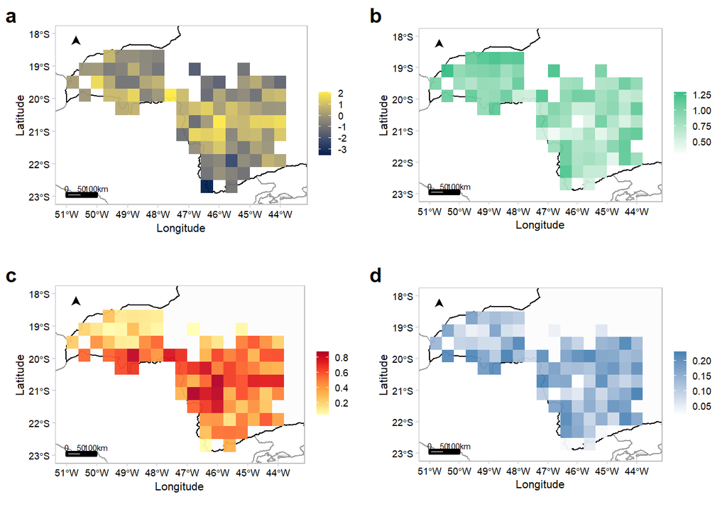

```r
plot_grid(g_spt_pc,
          g_spt_pc_sd,
          g1_pc,
          g1_pc_sd,
          labels = "auto",
          scale = 0.95)
```

```r
ggsave("figs/combo_pca.png", dpi = 300, height = 6, width = 10)
```

## Supplemental graphs

```r
Clime_map = function(data, var){

z = as.numeric(data[[var]])
data2 = data.frame(data[,c("x","y")],z)


g =data2 %>%
  # gather(c(4,5,7,8,10,11), key = "var", value = "value") %>%
ggplot()+
  geom_sf( data = BRA, fill = "white", color = "gray60")+
  geom_sf(data = MG, fill = "gray99", color = "black") +
  geom_tile(aes(x,y, fill = z    ),
            # fill ="gray60",
            size = .2,
            color = "gray65")+
  geom_point(data = hh_hlb,
             aes(lon, lat, color = presenca),
             size = 0.4)+
  scale_color_manual(values  =c("#3e9b39", 'red'))+
  scale_fill_viridis_c(option = "B")+
  coord_sf() +
  guides(color = guide_legend(override.aes = list(size=2.5)))+
  theme_minimal_grid(font_size = 8)+
  labs(x = "Longitude",
       y = "Latitude",
       color = "", fill = "")+
  north( location = "topleft", scale = 0.08, symbol = 10,
      x.min=-51, x.max=-43.5, y.min=-23, y.max=-18)+

  scalebar(location = "bottomleft", dist = 50,
           dist_unit = "km", transform = TRUE,
           x.min=-51, x.max=-44, y.min=-23, y.max=-18,
           st.bottom = FALSE,
           st.dist = 0.03, st.size = 2)+
  ylim(-23, -18)+
  xlim(-51, -43.5)+
  facet_wrap(~presenca)+
  theme(panel.border = element_rect(color = "gray"))
  return(g)
}
```

### Climate

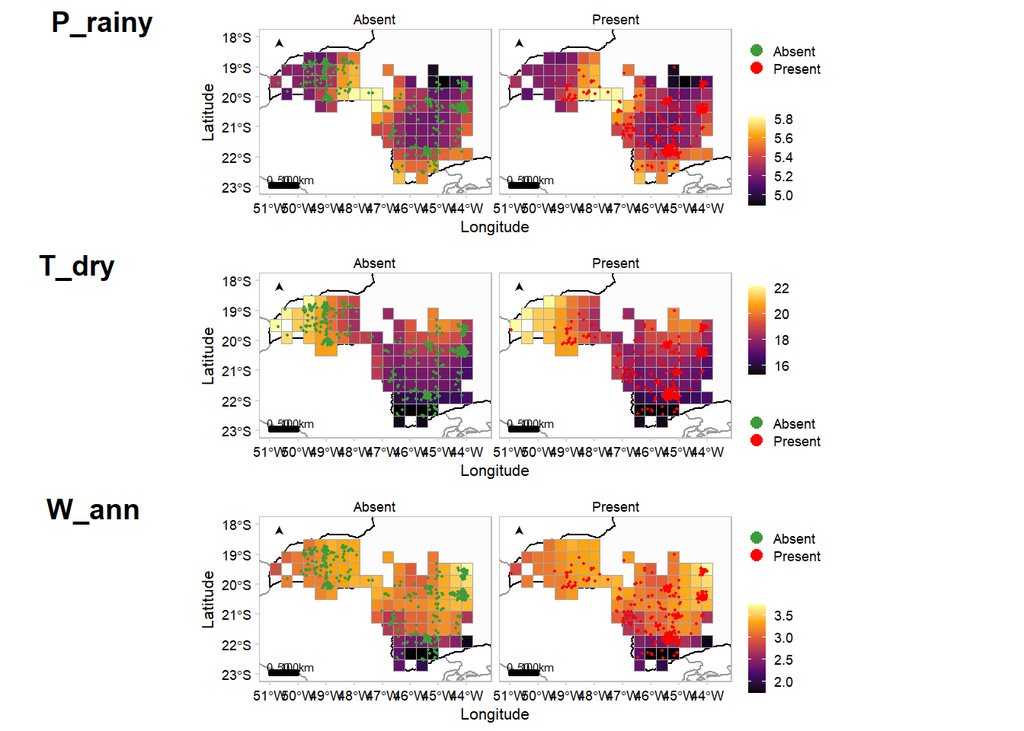

```r
plot_grid(

Clime_map(data=data, var="prec_rainy"),
Clime_map(data=data, var="temp_dry"),
Clime_map(data=data, var="wind_ann"),
ncol = 1,
labels = c("P_rainy", "T_dry","W_ann")
)
```

```r
ggsave("figs/clim_var_mapas.png", dpi=300, height = 10,width = 8)
```

### Orchard

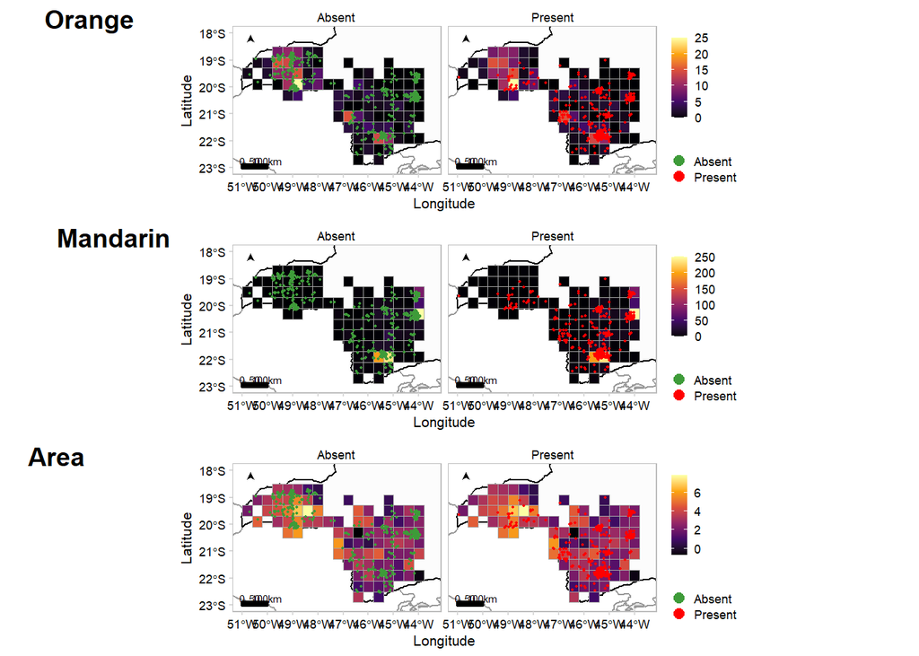

```r
plot_grid(

Clime_map(data=data, var="orange"),
Clime_map(data=data, var="mandarin"),
Clime_map(data=data, var="area"),
ncol = 1,
labels = c("Orange","Mandarin","Area")
)
```

```r
ggsave("figs/orchard_var_mapas.png", dpi=300, height = 8,width = 6)
```